# Bayesian Computing and MCMC

Lecture 14

# Last Classes

## The Bootstrap

Efron (1979) suggested combining estimation with simulation: the **bootstrap**.

**Key idea**: use the data to simulate a data-generating mechanism.

[figure not shown]

Baron von Munchhausen Pulling Himself By His Hair

Source: [Wikipedia](https://en.wikipedia.org/wiki/M%C3%BCnchhausen_trilemma)

## Why Does The Bootstrap Work?

Let $t_0$ the “true” value of a statistic, $\hat{t}$ the estimate of the statistic from the sample, and $(\tilde{t}_i)$ the bootstrap estimates.

- Variance: $\text{Var}[\hat{t}] \approx \text{Var}[\tilde{t}]$
- Then the bootstrap error distribution approximates the sampling distribution
  $$(\tilde{t}_i - \hat{t}) \overset{\mathcal{D}}{\sim} \hat{t} - t_0$$

## Bootstrap Variants

- Resample Cases (Non-Parametric)
- Resample Residuals (from fitted model trend)
- Simulate from Fitted Model (Parametric)

## Which Bootstrap To Use?

Depends on trust in model “correctness”: - Do we trust the model specification to be reasonably correct? - Do we trust that we have enough samples to recover the empirical CDF? - Do we trust the data-generating process?

# Bayesian Computing

## Sampling So Far

Rejection sampling (or importance sampling) to draw i.i.d. samples from a proposal density and reject/re-weight based on target.

Both require $f(x) \leq M g(x)$ for some $1 < M < \infty$.

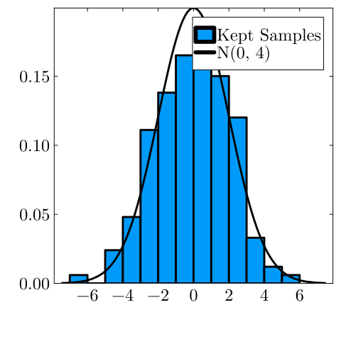

Figure 1: Example of rejection sampling for a Normal distribution

## Bayesian Computing Challenges

- Samples needed to compute posterior quantities (credible intervals, posterior predictive distributions, model skill estimates, etc.) with Monte Carlo.
- Posteriors often highly correlated.
- Grid approximation can help us visualize the posteriors in *low* dimensions.
- Rejection sampling scales poorly to higher dimensions.
- Conjugate priors only are appropriate in limited cases.

## What Would Make A Good Algorithm?

A wishlist:

- Don’t need to know the characteristics of the distribution.
- Samples will eventually be correctly distributed (given enough time).
- Ideally fast and requiring minimal tuning.

## How Can We Do This?

Suppose we want to sample a probability distribution $f(\cdot)$ and are at a parameter vector $x$.

What if we had a method that would let us stochastically jump from $x$ to a new vector $y$ in such a way that, eventually, we would visit any given vector wiith probability $f$?

This would let us trade convenience/flexibility for *dependent* samples.

## Markov Chain Monte Carlo (MCMC)

There is a mathematical process that has these properties: **Markov Chains**.

These methods are called **Markov chain Monte Carlo (MCMC)**.

# Markov Chains

## What Is A Markov Chain?

Consider a stochastic process $\{X_t\}_{t \in \mathcal{T}}$, where

- $X_t \in \mathcal{S}$ is the state at time $t$, and
- $\mathcal{T}$ is a time-index set (can be discrete or continuous)
- $\mathbb{P}(s_i \to s_j) = p_{ij}$.

[figure not shown]

Markov State Space

## Markovian Property

This stochastic process is a **Markov chain** if it satisfies the **Markovian (or memoryless) property**:
$$\begin{align*}
\mathbb{P}(X_{T+1} = s_i &| X_1=x_1, \ldots, X_T=x_T) = \\ &\qquad\mathbb{P}(X_{T+1} = s_i| X_T=x_T)
\end{align*}$$

## Example: “Drunkard’s Walk”

[figure not shown]

- How can we model the *unconditional* probability $\mathbb{P}(X_T = s_i)$?
- How about the *conditional* probability $\mathbb{P}(X_T = s_i | X_{T-1} = x_{T-1})$?

## Example: Weather

Suppose the weather can be foggy, sunny, or rainy.

Based on past experience, we know that:

1. There are never two sunny days in a row;
2. Even chance of two foggy or two rainy days in a row;
3. A sunny day occurs 1/4 of the time after a foggy or rainy day.

## Aside: Higher Order Markov Chains

Suppose that today’s weather depends on the prior *two* days.

1. Can we write this as a Markov chain?
2. What are the states?

## Weather Transition Matrix

We can summarize these probabilities in a **transition matrix** $P$:
$$P =
\begin{array}{cc}
\begin{array}{ccc}
\phantom{i}\color{red}{F}\phantom{i} & \phantom{i}\color{red}{S}\phantom{i} & \phantom{i}\color{red}{R}\phantom{i}
\end{array}
\\
\begin{pmatrix}
1/2 & 1/4 & 1/4 \\
1/2 & 0 & 1/2 \\
1/4 & 1/4 & 1/2
\end{pmatrix}
&
\begin{array}{ccc}
\color{red}F \\ \color{red}S \\ \color{red}R
\end{array}
\end{array}$$

## Weather Example: State Probabilities

Denote by $\lambda^t$ a probability distribution over the states at time $t$.

Then $\lambda^t = \lambda^{t-1}P$:

$$\begin{pmatrix}\lambda^t_F & \lambda^t_S & \lambda^t_R \end{pmatrix} =
\begin{pmatrix}\lambda^{t-1}_F & \lambda^{t-1}_S & \lambda^{t-1}_R \end{pmatrix}
\begin{pmatrix}
1/2 & 1/4 & 1/4 \\
1/2 & 0 & 1/2 \\
1/4 & 1/4 & 1/2
\end{pmatrix}$$

## Multi-Transition Probabilities

Notice that
$$\lambda^{t+i} = \lambda^t P^i,$$
so multiple transition probabilities are $P$-exponentials.

## Long Run Probabilities

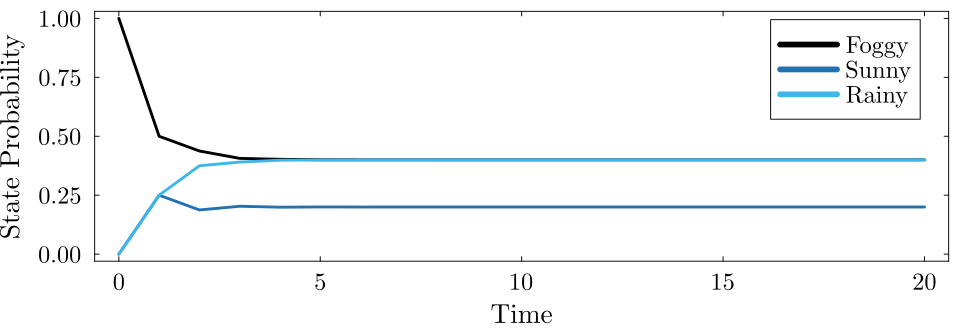

Figure 2: State probabilities for the weather examples.

```julia
current = [1.0, 0.0, 0.0]
P = [1/2 1/4 1/4
    1/2 0 1/2
    1/4 1/4 1/2]

T = 21

state_probs = zeros(T, 3)
state_probs[1,:] = current
for t=1:T-1
    state_probs[t+1, :] = state_probs[t:t, :] * P
end


p = plot(0:T-1, state_probs, label=["Foggy" "Sunny" "Rainy"], palette=:mk_8, linewidth=3)
xlabel!("Time")
ylabel!("State Probability")
plot!(p, size=(1000, 350))
```

## Stationary Distributions

This stabilization always occurs when the probability distribution is an eigenvector of $P$ with eigenvalue 1:

$$\pi = \pi P.$$

This is called an *invariant* or a *stationary* distribution.

## Which Markov Chains Have Stationary Distributions?

This is a property called **ergodicity** (or the chain is **ergodic**). Ergodic Markov chains always have a *limiting* distribution which is the limit of the time-evolution of the chain dynamics, *e.g.*
$$\pi_j = \lim_{t \to \infty} \mathbb{P}(X_t = s_j).$$

**Key**: The limiting distribution is *independent* of the initial state probability.

## Limiting Distributions are Stationary

For an ergodic chain, the limiting distribution is the unique stationary distribution (we won’t prove uniqueness):

$$\begin{align}
\pi_j &= \lim_{t \to \infty} \mathbb{P}(X_t = s_j | X_0 = s_i) \\
&= \lim_{t \to \infty} (P^{t+1})_{ij} = \lim_{t \to \infty} (P^tP)_{ij} \\
&= \lim_{t \to \infty} \sum_d (P^t)_{id} P_{dj} \\
&= \sum_d \pi_d P_{dj}
\end{align}$$

## MCMC and Ergodic Chains

Proving that a chain is ergodic is getting into the mathematical weeds a bit (and is outside the scope of this class).

**The good news**: The goal of any MCMC algorithm is to construct an ergodic chain where the stationary distribution $\pi(\cdot)$ is the target $f(\cdot)$.

This means that if you’re using a “standard” algorithm, the existence of a stationary distribution for the produced Markov chain is mathematically guaranteed.

## Transient Portion of the Chain

The portion of the chain prior to convergence to the stationary distribution is called the **transient** portion.

```julia
vspan!(p, [0, 4], color=:red, alpha=0.3, label="Transient Portion")
```

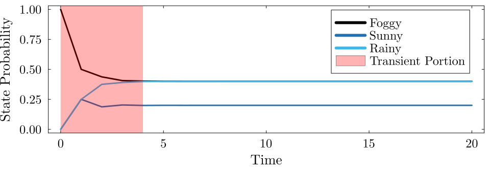

Figure 3: Transient portion of the weather Markov chain.

# Key Points and Upcoming Schedule

## Key Points (Bayesian Computing)

- Bayesian computation is difficult because we need to sample from effectively arbitrary distributions.
- Markov chains provide a path forward if we can construct a chain satisfying detailed balance whose stationary distribution is the target distribution.
- Then a post-convergence chain of samples is the same as a *dependent* Monte Carlo set of samples.

## Key Points (Markov Chains)

- Stochastic process with memoryless property.
- Some chains have a stationary distribution (eigenvector of transition matrix with eigenvalue 1).
- Ergodic Markov chains: dynamics converge to a limiting distribution, which is also stationary.

## Next Classes

**Monday**: MCMC

**Wednesday**: Cross-Validation and Model Skill

## Assessments

- **Homework 3**: Due Friday (3/14)
- **Project Proposal**: Due 3/21

# References

## References (Scroll for Full List)

Efron, B. (1979). Bootstrap methods: Another look at the jackknife. *Ann. Stat.*, *7*, 1–26. https://doi.org/10.1214/aos/1176344552